# RNAseq Analysis with kallisto/Chris Deitrick, pt. 3

```r
source(here("scripts", "deseq_workflow_expanded_mk3.r"), local=TRUE, echo=FALSE)
```

[output not shown]

# Setup again

A long string of notebooks. Previously, I had found that ribosomal RNA reads (86 features) were missing from the annotation tables, so I shuffled the original output into the “old” folder to save.

## Rerun kallisto with expanded index

The file I used to make the kallisto index did not include the rna transcripts, but they were included another file. So, I have appended both the _cds_from_genomic.fna and _rna_from_genomic.fna files together in a text editor, and saved as _cds_and_rna_from_genomic_unordered.fna. (Pushed them to my Beagle folder: /home/mjf123/BcenHI2424/TilS/TilS_RNA/data/indeces/) These are for the RefSeq versions. (There are GenBank ones, too.)

On Beagle, in the ~/mjf123/BcenHI2424/TilS/TilS_RNA/data/indeces/ folder:

```r
module load kallisto
kallisto index --index=HI2424.RS.cds.index GCA_000203955.1_ASM20395v1_cds_and_rna_from_genomic_unordered.fna
sh ../../scripts/TilSkallisto.sh
```

## Making a new feature table

As for the annotation table, GenBank has a cleaner version than what I had patched together listed as a tab-delineated _feature_table.txt. Every feature appears to be listed twice, once as a gene and then again as cds/RNA. The second listing has most of the information, except for the RNA feature that are missing an entry under “class.” (But not all entries are actually doubled, splitting them by even/odd indexes does not produce matching lists of locus_tags)

parse_GB_annotation filters out the duplicate information, writes a .tsv file for the run_on_kallisto.py script to use, and returns the annotation table.

```r
featurefile <- here::here("data", "references", "GCA_000203955.1_ASM20395v1_feature_table.txt")
anno_table <- parse_GB_annotation(featurefile)
nrow(anno_table)
```

```
[1] 7031
```

```r
featurefile <- here::here("data", "references", "GCF_000203955.1_ASM20395v1_feature_table.txt")
anno_table <- parse_RS_annotation(featurefile) # For RefSeq, use parse_GB_annotation for GenBank
nrow(anno_table)
```

```
[1] 7041
```

## Collect kallisto data into abundance table

Made new abundance tables using Chris Deitrick’s “run_on_kallisto.py” script, giving the new annotation table. (Moved old abundance tables into old_tables folder.) On beagle, from ~/BcenHI2424/TilS/TilS_RNA/:

```r
python scripts/run_on_kallisto.py --reference data/indeces/GCF_000203955.1_ASM20395v1_cds_and_rna_from_genomic_unordered.fna --folder results/results_kallisto/ --filename results/abundance.all.tsv --annotations data/indeces/RS.annotations.tsv
```

## Subsetting the data

And downloaded the three abundance tables. (These DESeq2 scripts only use the .matrix.tsv and .design.tsv)

```r
allMatrix <- read_table_counts(here::here("data", "abundance.all.matrix.tsv"))
nrow(allMatrix)
```

```
[1] 7041
```

```r
allDesign <- read_table_design(here::here("data", "abundance.all.design.tsv"))
annonames <- rownames(anno_table)
matrixnames <- rownames(allMatrix)
missingnames <- annonames[!(annonames %in% matrixnames)]
missing <- anno_table[missingnames, ]
```

Subetting first by type in the design tables, then using the design table names to subset the matrices.

```r
tilSDesign <- allDesign[(allDesign$type %in% "tils"), ]
tilSMatrix <- allMatrix[ , rownames(tilSDesign)]
ppcDesign <- allDesign[(allDesign$type %in% "ppc") | (allDesign$strain == "WT"), ]
ppcMatrix <- allMatrix[ , rownames(ppcDesign)]
```

# Rerunning DESeq2 with new annotation tables

Now, re-run everthing else….

```r
# Full data set: with and without chromosome 3
desOutFull <- des_workflow("results/DESeq2_Results_Full", allMatrix, "plmd", allDesign, anno_table)
```

```
[1] "Reading in the source tables..."
[1] "Filtering count matrix..."
[1] "Running deseq..."
[1] "Generating the Deseq matrix object..."
[1] "Generating the deseq object..."
```

```
[1] A244T N274Y N445K P421L S3C   T41T  tRNA  WT
Levels: A244T N274Y N445K P421L S3C T41T tRNA WT
```

```r
doFull <- des_workflow("results/DESeq2_Results_Full_noChrom3", allMatrix, "both", allDesign , anno_table)
```

```
[1] "Reading in the source tables..."
[1] "Filtering count matrix..."
[1] "Running deseq..."
[1] "Generating the Deseq matrix object..."
[1] "Generating the deseq object..."
```

## Filtering and collating pairwise results

Using padj < 0.1 as the cutoff. Create list of data frames with signficant genes only for each pairing, from within the list of datasets. (Adding annotation description column, too.)

```r
desresSig <- lapply(desres, function(matrixof) {
  lapply(matrixof[ ,1], function(df) {
    newdf <- df[order(df$pvalue), ]
    newdf <- subset(newdf, padj<0.1)
    newdf <- as.data.frame(newdf)
    newdf <- tibble::rownames_to_column(newdf, var="Gene")
    shortAno <- anno_table[anno_table$locusTag %in% newdf$Gene, ]
    newdf$annotation <- shortAno$name
    return (newdf)
  })
})
```

Collating pairwise results for each dataset, and writing to csv file in main results folder. Each gene can be listed multiple times, but will have column entries denoting with mutant compared to which mutant.

```r
desresCol <- lapply(nameKey, function(listitem){
  wordList <- as.list(names(desresSig[[listitem]]))
  newdf <- mapply( function(df, w ) {words <- unlist(strsplit(w, "_to_", fixed=TRUE))
    df <- cbind( df, "mutant"=rep(words[[1]], nrow(df)),
                        "comparedTo"=rep(words[[2]], nrow(df)))
    }, desresSig[[listitem]], wordList, SIMPLIFY = FALSE, USE.NAMES = FALSE)
  collated <- do.call(rbind, newdf)
  newfile <- here::here("results", paste0("collated_sigRes_",listitem,".csv"))
  write.csv(collated, file=newfile, row.names = FALSE)
  return (collated)
})
```

# Rlog transformation

Using the rlog transformations, as the data set is less than 30. ([For reasoning](https://bioconductor.org/packages/release/workflows/vignettes/rnaseqGene/inst/doc/rnaseqGene.html#the-variance-stabilizing-transformation-and-the-rlog)) Chose a non-blind transformation, because we expect to see differences dependent on mutant. See also a discussion on the [blind parameter.](https://bioconductor.org/packages/release/bioc/vignettes/DESeq2/inst/doc/DESeq2.html#blind-dispersion-estimation)

The DESeq2Transform objects produced can be given to pcaExplorer as well.

```r
rld <- lapply(setNames(nameKey, nameKey), function(listitem){
  rlog(dds[[listitem]], blind=FALSE)
})
```

## Heatmaps of the transformed count matrix

Creating heatmaps from each of the rlog transformations.

```r
selector <- vector("list", 8)
selector <- lapply(setNames(nameKey,nameKey), function(listitem){
  order(rowMeans(counts(dds[[listitem]], normalized=TRUE)), decreasing=TRUE)[1:20]
})

titles <- c("Full Data Set", "Full Data Set, without chromosome 3",
            "TilS Subset", "TilS Subset, without chromosome 3",
            "PPC Subset", "PPC Subset, without chromosome 3")
names(titles) <- nameKey
df <- as.data.frame(colData(dds[[1]])[,c("strain","type")]) #this is just a key

dir.create(here::here("results", "count_heatmaps"), showWarnings = FALSE)
heatmaps <- lapply(setNames(nameKey,nameKey), function(listitem){
  pheatmap(assay(rld[[listitem]])[selector[[listitem]],], cluster_rows=FALSE, show_rownames=FALSE,
           cluster_cols=FALSE, annoation_col=df, color = magma(255, begin = 0.15),
           main = paste0("Heatmap of Count Matrix for ", titles[[listitem]]),
           filename = here::here("results", "count_heatmaps", paste0("rld_heatmap_", listitem, ".pdf")))
})
```

## Clustering

With the transformations, create clusterings based on distances, and save plots.

Plot and save all of the clusterings in one file. (To create separate files, comment out the pdf and dev lines here, and then uncomment the same lines within the function in the deseq_workflow_expanded_mk3.r script. Creating a funciton for later use fixed problems with the lapply call.)

```r
dir.create(here::here("results", "rld_clustering"), showWarnings = FALSE)
# pdf(file=here::here("results", "rld_clustering", "rldclusterings_All.pdf"))
rldclusters <- lapply(nameKey, function(listitem){
  fname <- here::here("results", "rld_clustering", paste0("rldclustering_", listitem, ".pdf"))
  clustering_plot(sampleDists[[listitem]], rld[[listitem]], colors, titles[[listitem]], fname)
})
# dev.off()
```

## Clustering by top variance (not using log2 differential)

```r
topVarGenes <- lapply(setNames(nameKey,nameKey), function(listitem){
  head(order(rowVars(assay(rld[[listitem]])), decreasing = TRUE), 50)
})
topVarEntries <- vector("list", length(nameKey))
topVarEntries <- lapply(setNames(nameKey, nameKey), function(listitem){
  topVarEntries[[listitem]]  <- assay(rld[[listitem]])[ topVarGenes[[listitem]], ]
})
dir.create(here::here("results", "topGenes_byVariance_acrossDataset"), showWarnings = FALSE)
topVarEntriesAno <- vector("list", length(nameKey))
topVarEntriesAno <- lapply(setNames(nameKey, nameKey), function(listitem){
  topVarEntriesAno[[listitem]] <- tibble::rownames_to_column(as.data.frame(topVarEntries[[listitem]]), var="locusTag")
  shortAno <- anno_table[anno_table$locusTag %in% topVarEntriesAno[[listitem]]$locusTag, ]
  topVarEntriesAno[[listitem]]$name <- shortAno$name
  fname <- here::here("results", "topGenes_byVariance_acrossDataset", paste0("TopVarianceGenes_",listitem,".csv"))
  write.csv(topVarEntriesAno[[listitem]], file=fname, row.names=FALSE)
})
```

```r
pheat <- lapply(setNames(nameKey, nameKey), function(listitem){
  mat  <- topVarEntries[[listitem]] - rowMeans(topVarEntries[[listitem]])
  anno <- as.data.frame(colData(rld[[listitem]])[, c("strain","type")])
  fname <- here::here("results", "topGenes_byVAriance_acrossDataset", paste0("geneVarCluster_", listitem, ".pdf"))
  pheatmap(mat, annotation_col = anno, fontsize_number = 2,
           cellwidth = 12, cellheight = 9,
           main=paste0("Clustering of Highest Variance Genes for ", titles[[listitem]]),
           filename = fname)
})
```

*Other clustering schema?*

# PCA plots

Set a color scheme so that each mutant stays the same color.

```r
mutantColors <- brewer.pal(8, "Set1")
names(mutantColors) <- levels(allDesign$strain)
```

Create, save, and store pca plots. (dimentions could be defined in the ggsave call)

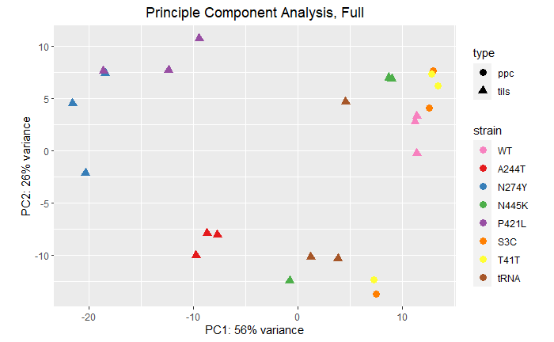

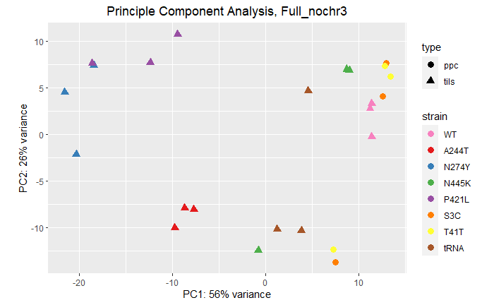

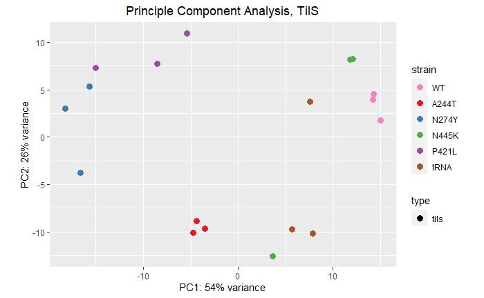

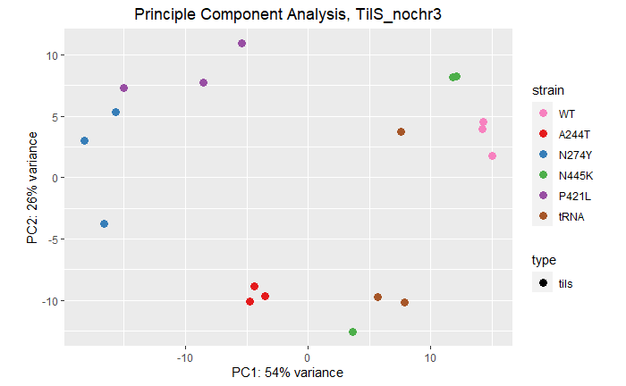

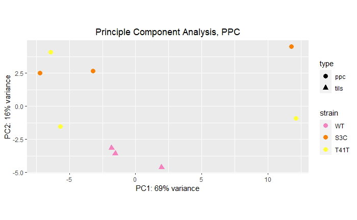

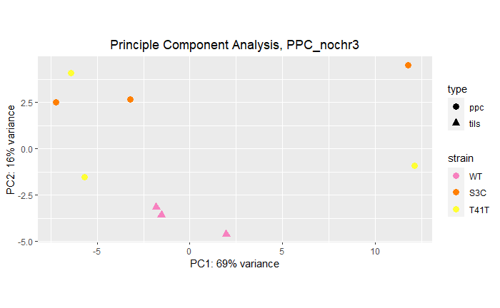

```r
dir.create(here::here("results","pca"), showWarnings = FALSE)
pcas <- lapply(setNames(nameKey,nameKey), function(listitem) {
  pcaData <- plotPCA(rld[[listitem]], intgroup=c("strain", "type"), returnData=TRUE)
  percentVar <- round(100 * attr(pcaData, "percentVar"))
  fname <- here::here("results", "pca", paste0("pcaPlot_", listitem, ".pdf"))
  p <- ggplot(pcaData, aes(PC1, PC2, color=strain, shape=type)) +
    geom_point(size=3) +
    xlab(paste0("PC1: ",percentVar[1],"% variance")) +
    ylab(paste0("PC2: ",percentVar[2],"% variance")) +
    coord_fixed() +
    ggtitle(paste0("Principle Component Analysis, ",listitem)) +
    theme(plot.title = element_text(hjust = 0.5)) +
    scale_color_manual(values = mutantColors)
  ggsave(fname, device = "pdf")
  plot(p)
})
```

## PCA EXplorer

The interacitve viewer is useful for grabbing the top and bottom loading genes for each principle component. Adding a column to add the gene description to the locus tag.

```r
anno_table$gene_name <- paste(anno_table$locusTag, anno_table$symbol, anno_table$name, sep = "-")
```

Running pcaExplorer on each data set. Mostly interested in the TilS and PPC subsets. Saving the top/bottom loading genes, expression projections, and the variance explained by PC (scree). (I don’t think that I need to use any of the options on the first tab since I’m uploading already transformed data.) Also, trying to save more than 15 top/bottom loading genes in the sample tab loses some text. Settings: Let nr of most variant gene be 300. The loadings plots need to be spaced out better in Inkscape. (I think that those loadings are the same as the top variance genes calculated earlier. But would like to verify and look to plot the CI ovals manually for more control?) Also able to to see what it looks like to leave out N445K3 and tRNA2 as possible outliers. Groupings don’t change too much.

```r
pcaExplorer(dds = dds[["TilS"]], dst = rld[["TilS"]], coldata = tilSDesign, annotation = anno_table)
```

```
Listening on http://127.0.0.1:5836
```

[output not shown]

```
NA
```

```r
pcaExplorer(dds = dds[["TilS_nochr3"]], dst = rld[["TilS_nochr3"]], coldata = tilSDesign, annotation = anno_table)
```

```
Listening on http://127.0.0.1:5836
```

```
you provided 10 unique identifiers
10 out of 10 provided genes were found in the datayou provided 36 unique identifiers
36 out of 36 provided genes were found in the datayou provided 9 unique identifiers
9 out of 9 provided genes were found in the data
```

```
NA
```

```r
pcaExplorer(dds = dds[["PPC"]], dst = rld[["PPC"]], coldata = ppcDesign, annotation = anno_table)
```

```
Listening on http://127.0.0.1:5836
```

```
you provided 11 unique identifiers
11 out of 11 provided genes were found in the datayou provided 6 unique identifiers
6 out of 6 provided genes were found in the datayou provided 4 unique identifiers
4 out of 4 provided genes were found in the datayou provided 5 unique identifiers
5 out of 5 provided genes were found in the datayou provided 5 unique identifiers
5 out of 5 provided genes were found in the datayou provided 5 unique identifiers
5 out of 5 provided genes were found in the data
```

```
NA
```

```r
pcaExplorer(dds = dds[["PPC_nochr3"]], dst = rld[["PPC_nochr3"]], coldata = ppcDesign, annotation = anno_table)
```

```
Listening on http://127.0.0.1:5836
```

```r
pcaExplorer(dds = dds[["Full"]], dst = rld[["Full"]], coldata = allDesign, annotation = anno_table)
```

```
Listening on http://127.0.0.1:5836
```

```
you provided 20 unique identifiers
20 out of 20 provided genes were found in the datayou provided 31 unique identifiers
31 out of 31 provided genes were found in the data
```

```
NA
```

```r
pcaExplorer(dds = dds[["Full_nochr3"]], dst = rld[["Full_nochr3"]], coldata = allDesign, annotation = anno_table)
```

```
Listening on http://127.0.0.1:5836
```

```
you provided 4 unique identifiers
4 out of 4 provided genes were found in the datayou provided 6 unique identifiers
6 out of 6 provided genes were found in the datayou provided 4 unique identifiers
4 out of 4 provided genes were found in the datayou provided 4 unique identifiers
4 out of 4 provided genes were found in the datayou provided 4 unique identifiers
4 out of 4 provided genes were found in the datayou provided 4 unique identifiers
4 out of 4 provided genes were found in the datayou provided 1 unique identifiers
1 out of 1 provided genes were found in the datayou provided 11 unique identifiers
11 out of 11 provided genes were found in the datayou provided 10 unique identifiers
10 out of 10 provided genes were found in the datayou provided 12 unique identifiers
12 out of 12 provided genes were found in the datayou provided 12 unique identifiers
12 out of 12 provided genes were found in the datayou provided 94 unique identifiers
94 out of 94 provided genes were found in the data
```

```
NA
```

Table export options are down at the bottom of the genes panel: look at tightly clustered genes? (Full data set is actually interesting to see in that window.)

# Gviz?

*Current goals:*

*Attaching the GRanges data to the DESEqDataSets. +Do I need rtracklayer?* gviz up and running, requires pairwise comparisons… and grange, and lfcShrink *Back through pcaExplorer, look at gene tab

(remove tRNA mutant from TilS set and see how things change? The ribosomal RNA appears to be dominating results. Should I remove only the ribosomal?)

```r
library(GenomicFeatures)
txdb <- makeTxDbFromGFF(here::here("data", "references", "GCA_000203955.1_ASM20395v1_genomic.gff"))
```

```
Import genomic features from the file as a GRanges object ... OK
Prepare the 'metadata' data frame ... OK
Make the TxDb object ... OK
```

```r
txdb
```

```
TxDb object:
# Db type: TxDb
# Supporting package: GenomicFeatures
# Data source: C:/Users/mjf123/Documents/tilS/RNAseq/data/references/GCA_000203955.1_ASM20395v1_genomic.gff
# Organism: NA
# Taxonomy ID: NA
# miRBase build ID: NA
# Genome: NA
# transcript_nrow: 7005
# exon_nrow: 7005
# cds_nrow: 6919
# Db created by: GenomicFeatures package from Bioconductor
# Creation time: 2020-06-13 04:31:45 -0400 (Sat, 13 Jun 2020)
# GenomicFeatures version at creation time: 1.38.2
# RSQLite version at creation time: 2.2.0
# DBSCHEMAVERSION: 1.2
```

```r
txdbRS <- makeTxDbFromGFF(here::here("data", "references", "GCF_000203955.1_ASM20395v1_genomic.gff")) # RefSeq?
```

```
Import genomic features from the file as a GRanges object ... OK
Prepare the 'metadata' data frame ... OK
Make the TxDb object ... The following transcripts were dropped because their exon ranks could not be inferred (either because the
  exons are not on the same chromosome/strand or because they are not separated by introns):
  gene-BCEN2424_RS16455, gene-BCEN2424_RS17110, gene-BCEN2424_RS33785, gene-BCEN2424_RS34535OK
```

```r
txdbRS
```

```
TxDb object:
# Db type: TxDb
# Supporting package: GenomicFeatures
# Data source: C:/Users/mjf123/Documents/tilS/RNAseq/data/references/GCF_000203955.1_ASM20395v1_genomic.gff
# Organism: NA
# Taxonomy ID: NA
# miRBase build ID: NA
# Genome: NA
# transcript_nrow: 7037
# exon_nrow: 7038
# cds_nrow: 6947
# Db created by: GenomicFeatures package from Bioconductor
# Creation time: 2020-06-13 04:31:48 -0400 (Sat, 13 Jun 2020)
# GenomicFeatures version at creation time: 1.38.2
# RSQLite version at creation time: 2.2.0
# DBSCHEMAVERSION: 1.2
```

It looks like the GenBank version doesn’t include the RNA features, but the RefSeq does. cds nrow is different, too. RefSeq dropped: gene-BCEN2424_RS16455, gene-BCEN2424_RS17110, gene-BCEN2424_RS33785, gene-BCEN2424_RS34535OK